# Delays in clinical detection: impact on stage at diagnosis

## Objectives

To assess how a delay in clinical detection affects

- the distribution of stage at diagnosis in absence of screening.
- the events in a screening trial that lead to an observed change in late stage disease diagnosed between the two arms.

Last time, preliminary results showed that, contrary to expectations, we saw reduced stage shift given a delay in clinical diagnosis in both arms. Do these results hold up to further scrutiny, and if so, what explains them?

## Methods

The five-state disease progression model is shown in Figure 1.

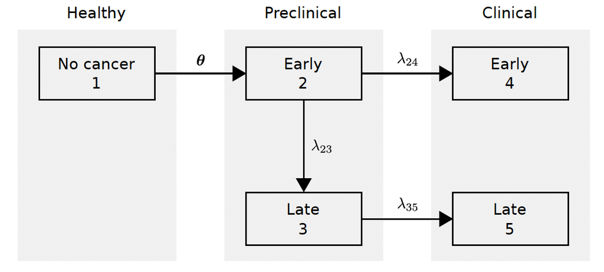

Figure 1: Five state natural history model used in MCEDsim.

- Based on the formula in (Lange et al. 2024),the overall mean preclinical duration from the 5-state model is specified as

$$OMST=\frac{1}{\lambda_{23} + \lambda_{24}}+\frac{\lambda_{23}}{\lambda_{23} + \lambda_{24}}\cdot \frac{1}{\lambda_{35}}$$

- We modeled a delay in detection by increasing the OMST by delta, maintaining $\lambda_{23}$, and assuming a multiplicative impact on the rates $\lambda_{24}$ and $\lambda_{35}$. That is,

$$OMST+\delta=\frac{1}{\lambda_{23} + \lambda_{24} x}+\frac{\lambda_{23}}{\lambda_{23} + \lambda_{24} x}\cdot \frac{1}{\lambda_{35} x}$$

Solving for x, we obtain

$$x= \frac{\lambda_{35}\!\left(1 - (\mathrm{OMST} + \delta)\lambda_{23}\right)\pm\sqrt{\left((\mathrm{OMST} + \delta)\lambda_{35}\lambda_{23} - \lambda_{35}\right)^2+ 4(\mathrm{OMST} + \delta)\lambda_{35}\lambda_{24}\lambda_{23}}}{2(\mathrm{OMST} + \delta)\lambda_{35}\lambda_{24}}$$

We use the positive root in the solution.

To explore the impact of delaying clinical diagnosis in a screening trial, we use lung cancer as an example, assuming an OMST of 2 years and an LMST of .5 years. We assume individuals start the trial at age 60, and that are three annual screens and one additional year of follow-up.

We vary $\delta$ from 0 to 1 years and consider the impact on

- Distribution of late and early and late stage disease in absence of screening
- Screen detected late stage disease in the screen arm
- Interval-detected late stage disease in the screen arm
- Clinical late stage disease in the control arm
- Stage shift by screen
- Cumulative stage shift

## Code

```r
library(MCEDsim)
library(dplyr)
library(ggplot2)
library(here)
library(patchwork)


source(here("Code/stage_shift_code_sean.R"))
source(here("Code/natural_history_code_sean.R"))

#load rate matrices from MCEDsim package
data("combined_fits")


solve_for_x <- function(lambda23, lambda24, lambda35, OMST, y) {

  k <- OMST + y

  # Quadratic coefficients
  A <- k * lambda35 * lambda24
  B <- k * lambda35 * lambda23 - lambda35
  C <- -lambda23

  # Discriminant
  disc <- B^2 - 4 * A * C

  if (disc < 0) {
    stop("No real solution: discriminant < 0")
  }

  # Quadratic formula (simplified closed form)
  x1 <- (lambda35 * (1 - k * lambda23) +
           sqrt((k * lambda35 * lambda23 - lambda35)^2 +
                  4 * k * lambda35 * lambda24 * lambda23)) /
    (2 * k * lambda35 * lambda24)

  x2 <- (lambda35 * (1 - k * lambda23) -
           sqrt((k * lambda35 * lambda23 - lambda35)^2 +
                  4 * k * lambda35 * lambda24 * lambda23)) /
    (2 * k * lambda35 * lambda24)

  roots <- c(x1, x2)

  # Filter for positive X only
  positive_roots <- roots[roots > 0]

  return(positive_roots)
}

get_adjusted_stage_shift<-function(delta,the_cancer_site,the_OMST, the_LMST, the_sex="Male"){
 #Extract rate matrix from array of rates
  the_index = all_meta_data_male %>% filter(cancer_site=="Lung",OMST==2, LMST==.5,sex==the_sex)
  rate_mat=all_rates_male[,,the_index$index]
  #dimension of rate matrix
  k=dim(rate_mat)[1]

  #original transition rates between pre-clinical and clinical states
  lambda35=rate_mat[k-2,k]
  lambda23=rate_mat[k-3,k-2]
  lambda24=rate_mat[k-3,k-1]

  #solve for rate multiplier given delta
  out=try(solve_for_x(lambda23=lambda23,lambda24=lambda24,lambda35=lambda35,OMST=the_OMST,y=delta))

  x=out[1]
  # Update rate matrix
  new_rate=rate_mat
  #set new lambda24
  new_rate[k-3,k-1]=lambda24*x
  #set new lambda35
  new_rate[k-2,k]=lambda35*x

  old_EMST=1/(lambda23+lambda24)
  old_LMST=1/(lambda35)
  old_OMST=1/(lambda23+lambda24)+(lambda23/(lambda23+lambda24))*(1/(lambda35))

  new_OMST=1/(lambda23+lambda24*x)+(lambda23/(lambda23+lambda24*x))*(1/(lambda35*x))
  new_EMST=1/(lambda23+lambda24*x)
  new_LMST=1/(lambda35*x)

  #get stage shift
  outtable=stage_shift_by_screen(numscreens = 3,age=60,screen.int=1,sens_l=.9,sensitivities_e = .5,
                                 rateout=new_rate,
                                 num.followup.intervals=1)
  outtable$delta=delta
  outtable$x=x
  outtable$new_OMST=new_OMST
  outtable$new_LMST=new_LMST
  outtable$new_EMST=new_EMST
  outtable$old_OMST=old_OMST
  outtable$old_LMST=old_LMST
  outtable$old_EMST=old_EMST

  #get old and new age specific incidence
  new_incidence=incidence_rate(new_rate)%>%mutate(delta=factor(delta))

  #plot old and new age-specific incidence

  return(list(outtable=outtable,new_incidence=new_incidence))

}

incidence_rate<-function(rate_mat){
 ages=seq(0,80,by=.5)
   k=dim(rate_mat)[1]
    pred_cause_spec_hazards<-mapply(ages,FUN="cause_spec_hazards",MoreArgs=list(rate_mat=rate_mat,k=k))
    pred=c(unlist(pred_cause_spec_hazards[1,])*1e5,unlist(pred_cause_spec_hazards[2,])*1e5)

    pred_data=data.frame(age=rep(ages,times=2),stage=rep(c("Early","Advanced"),each=length(ages)),predicted_rate=pred)

    return(pred_data)
}

allout=mapply(seq(0,1,by=.1),FUN=get_adjusted_stage_shift, MoreArgs = list(the_cancer_site="Lung",the_OMST=2,the_LMST=.5,the_sex="Male"),SIMPLIFY = F)

all_incidence=do.call(rbind,lapply(allout,"[[","new_incidence"))

all_stage_shift=do.call(rbind,lapply(allout,"[[","outtable"))%>%mutate(delta=factor(delta))


p1=ggplot(data=all_stage_shift,aes(y=new_OMST,x=delta))+geom_point()+ggtitle("Delta versus New OMST")
p2=ggplot(data=all_stage_shift,aes(y=new_EMST,x=delta))+geom_point()+ggtitle("Delta versus New EMST")
p3=ggplot(data=all_stage_shift,aes(y=new_LMST,x=delta))+geom_point()+ggtitle("Delta versus New LMST")


p4=ggplot(data=all_incidence,aes(x=age,y=predicted_rate))+geom_line(aes(group=delta,color = delta))+
  facet_grid(~stage)+xlab("Age")+ylab("Rate/100,000")+coord_cartesian(xlim=c(45,75))+ggtitle("Projected age- and stage-specific incidence under different deltas")

p5=ggplot(data=all_stage_shift,aes(y=control_late*1e5,x=interval))+geom_point(aes(color=delta))+geom_line(aes(color=delta,group=delta))+ggtitle("Projected late stage disease in control arm under different deltas")


p6=ggplot(data=all_stage_shift,aes(y=screen_late*1e5,x=interval))+geom_point(aes(color=delta))+geom_line(aes(color=delta,group=delta))+ggtitle("Projected screen-detected late-stage disease (screen arm) under different deltas")

p7=ggplot(data=all_stage_shift,aes(y=interval_late*1e5,x=interval))+geom_point(aes(color=delta))+geom_line(aes(color=delta,group=delta))+ggtitle("Projected interval-detected stage disease (screen arm) under different deltas")

p8=ggplot(data=all_stage_shift,aes(y=stage_shift_by_interval,x=interval))+geom_point(aes(color=delta))+geom_line(aes(color=delta,group=delta))+ggtitle("Projected stage-shift by interval under different deltas")

p9=ggplot(data=all_stage_shift,aes(y=cumulative_stage_shift,x=interval))+geom_point(aes(color=delta))+geom_line(aes(color=delta,group=delta))+ggtitle("Projected stage-shift by interval under different deltas")
```

## Results

### Basic checks on sojourn times for across different delays

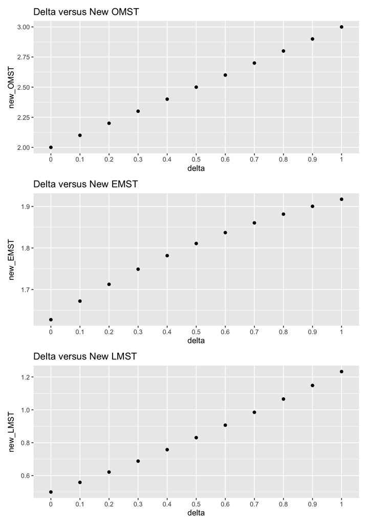

Figure 2: Checks on updated OMST, EMST, and LMST for various values of delta. Baseline OMST=2 years, EMST=1.63 years, LMST=.5 years, lambda_{23}= 0.4581298

### Impact of delays (delta) on age- and stage-specific incidence

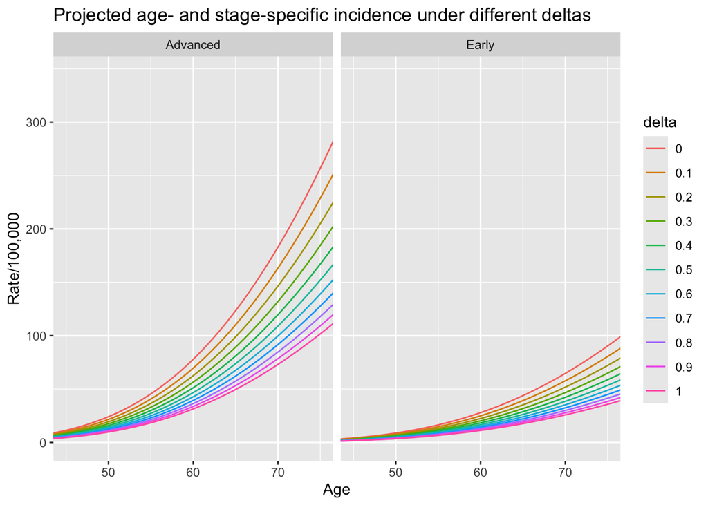

Figure 3: Age and stage-specific incidence in absence of screening for different values of delta

### Impact of delays (delta) on 3-screen trial outcomes

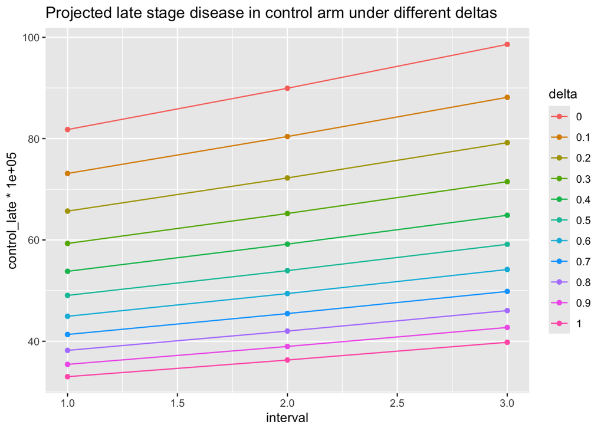

Figure 4: Late stage incidence in control arm under different values of delta

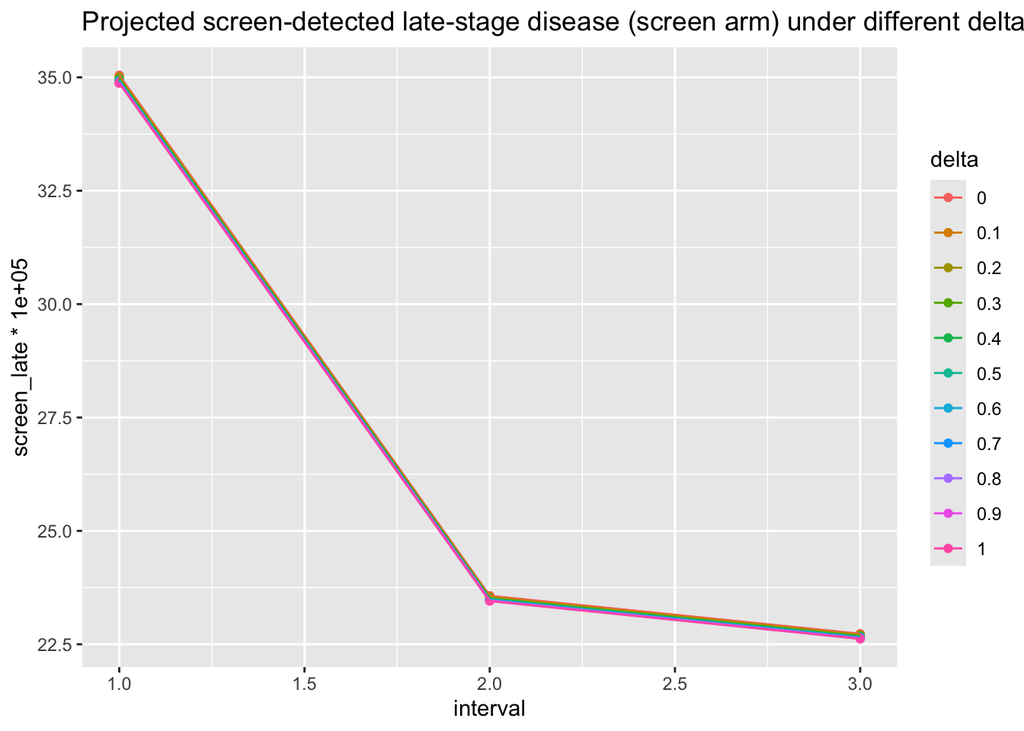

Figure 5: Projected screen-detected late-stage disease (screen arm) under different deltas

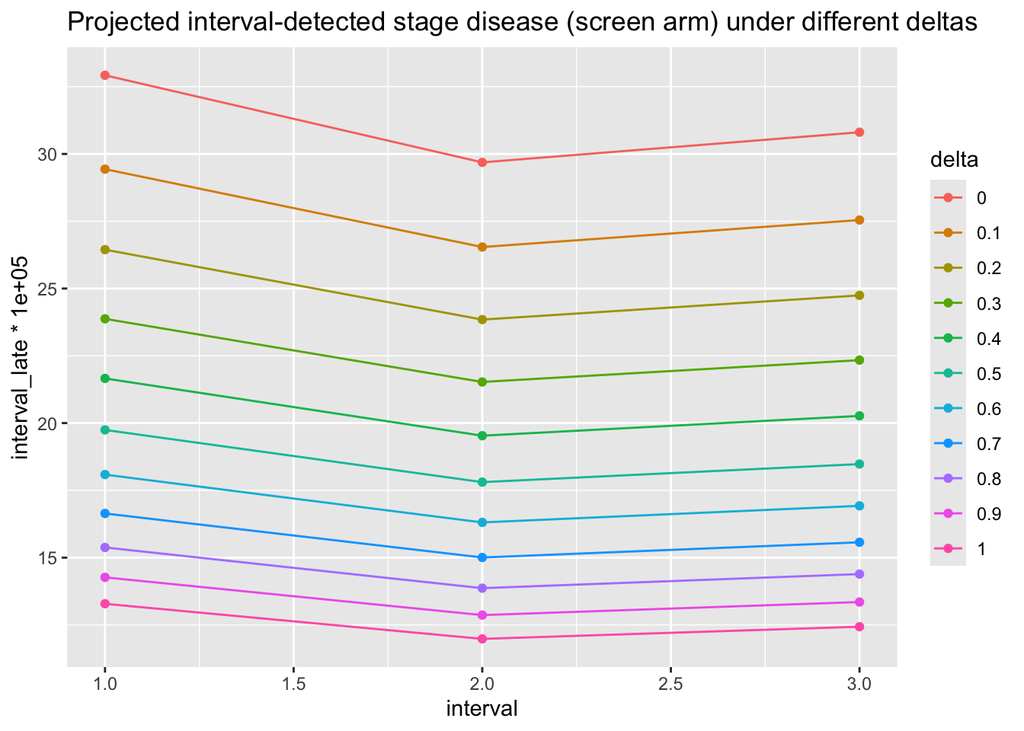

Figure 6: Projected interval-detected late-stage disease (screen arm) under different deltas

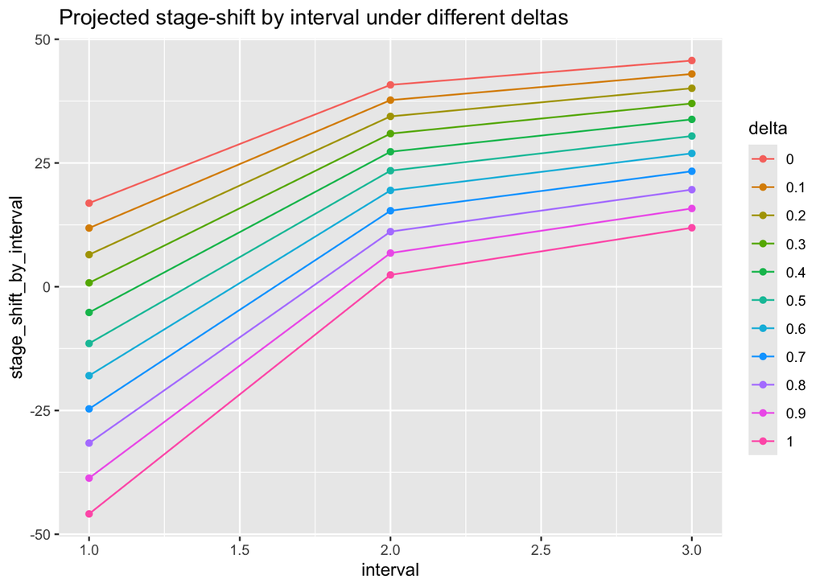

Figure 7: Projected stage shift by screen/interval (relative reduction in late stage disease between control and screen arms) under different deltas

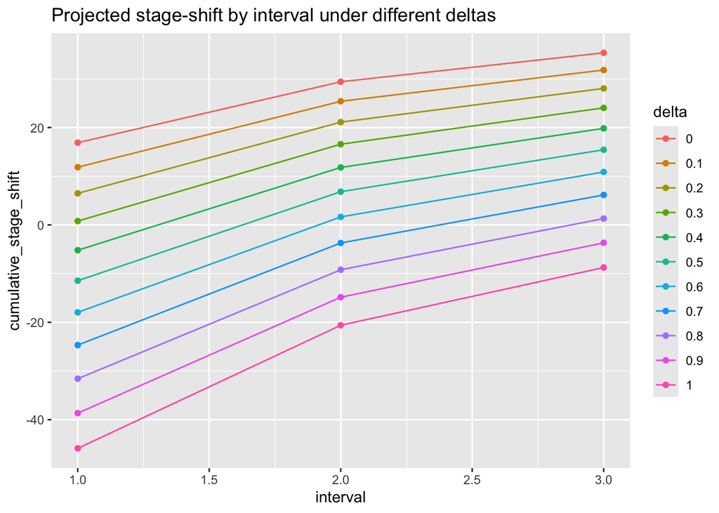

Figure 8: Projected cumulative stage shift (relative reduction in late stage disease between control and screen arms) under different deltas

[output not shown]